# Latihan Pertemuan 4

Bagas

2025-09-25

# Nomor 1

## Bangkitkan Model MA(2), Plot Identifikasi, dan Analisis Stasioneritas

```r
# Atur parameter
set.seed(123) # Untuk reproduktifitas hasil
n <- 300
theta1 <- 0.4
theta2 <- 0.6

# Bangkitkan white noise (e_t)
# Kita butuh 2 nilai awal tambahan untuk e_{t-1} dan e_{t-2}
e <- rnorm(n + 2, mean = 0, sd = 1)

# Siapkan vektor untuk Y_t
Yt <- numeric(n)

# Lakukan perulangan untuk membangkitkan Y_t
for (t in 1:n) {
  # Rumus: Yt = e_t - θ1*e_{t-1} - θ2*e_{t-2}
  # Indeks e disesuaikan karena e[1] adalah e_{-1}, e[2] adalah e_{0}, dst.
  Yt[t] <- e[t + 2] - theta1 * e[t + 1] - theta2 * e[t]
}


library(TSA)
```

```
## AR/MA
##   0 1 2 3 4 5 6 7 8 9 10 11 12 13
## 0 x x o o o o o o o o o  o  o  o
## 1 x x x o o o o o o o o  o  o  o
## 2 x x o o o o o x o o o  o  o  o
## 3 x x o o o o o x o o o  o  o  o
## 4 x x x x o x o o o o o  o  o  o
## 5 x x o x o x x o o o o  o  o  o
## 6 x x o o x x x o o o o  o  o  o
## 7 x x o o o x x o o o o  o  o  o
```

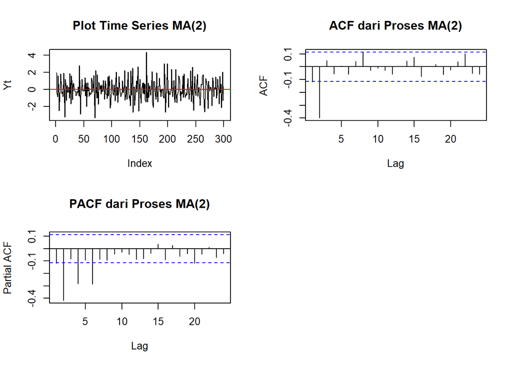

```r
# Atur layout plot menjadi 2x2
par(mfrow = c(2, 2))

# 1. Plot Time Series
plot(Yt, main = "Plot Time Series MA(2)", ylab = "Yt", type = "l")
abline(h = mean(Yt), col = "red") # Garis rata-rata

# 2. Plot ACF
acf(Yt, main = "ACF dari Proses MA(2)")

# 3. Plot PACF
pacf(Yt, main = "PACF dari Proses MA(2)")

# 4. Plot EACF
eacf(Yt)
```

## Scatterplot

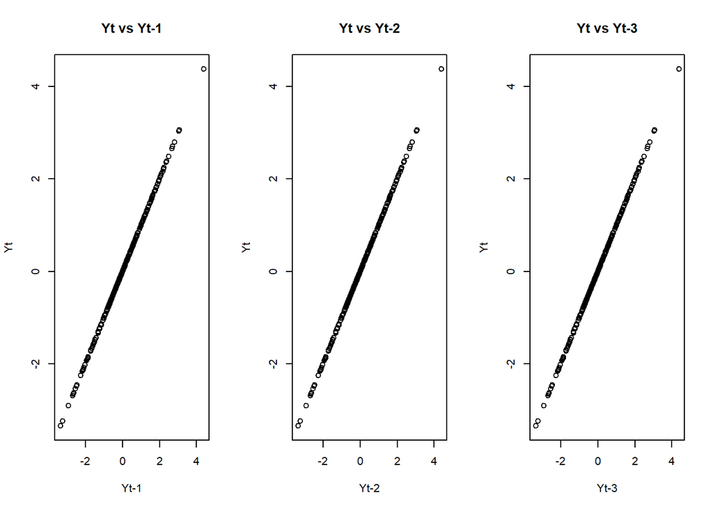

```r
# Reset layout plot
par(mfrow = c(1, 3))

# Yt vs Yt-1
plot(lag(Yt, -1), Yt, main = "Yt vs Yt-1", xlab="Yt-1")

# Yt vs Yt-2
plot(lag(Yt, -2), Yt, main = "Yt vs Yt-2", xlab="Yt-2")

# Yt vs Yt-3
plot(lag(Yt, -3), Yt, main = "Yt vs Yt-3", xlab="Yt-3")
```

## Autokorelasi

### Autokorelasi Empiris (dari Data)

```r
acf_values <- acf(Yt, plot = FALSE)
print(paste("Autokorelasi Empiris Lag 1 (ρ1):", round(acf_values$acf[1], 4)))
```

```
## [1] "Autokorelasi Empiris Lag 1 (ρ1): -0.1165"
```

```r
print(paste("Autokorelasi Empiris Lag 2 (ρ2):", round(acf_values$acf[2], 4)))
```

```
## [1] "Autokorelasi Empiris Lag 2 (ρ2): -0.399"
```

```r
print(paste("Autokorelasi Empiris Lag 3 (ρ3):", round(acf_values$acf[3], 4)))
```

```
## [1] "Autokorelasi Empiris Lag 3 (ρ3): 0.0473"
```

### Autokorelasi Teoretis

```r
rho1_teori <- (-theta1 + theta1 * theta2) / (1 + theta1^2 + theta2^2)
rho2_teori <- -theta2 / (1 + theta1^2 + theta2^2)

print(paste("Autokorelasi Teoretis Lag 1 (ρ1):", round(rho1_teori, 4)))
```

```
## [1] "Autokorelasi Teoretis Lag 1 (ρ1): -0.1053"
```

```r
print(paste("Autokorelasi Teoretis Lag 2 (ρ2):", round(rho2_teori, 4)))
```

```
## [1] "Autokorelasi Teoretis Lag 2 (ρ2): -0.3947"
```

```r
print("Autokorelasi Teoretis Lag 3 (ρ3): 0")
```

```
## [1] "Autokorelasi Teoretis Lag 3 (ρ3): 0"
```

Stasioneritas: Plot deret waktu (Time Series) menunjukkan data berfluktuasi di sekitar rata-rata yang konstan (garis merah) dan tidak menunjukkan adanya tren. Ini adalah ciri visual dari data yang stasioner.

Identifikasi MA(2):

Plot ACF secara jelas terpotong (cuts off) setelah lag ke-2. Ini adalah karakteristik utama dari proses MA(q), di mana q=2.

Plot PACF cenderung meluruh (tails off) setelah lag ke-2. Pola ACF yang cuts off dan PACF yang tails off adalah penanda klasik untuk model MA.

Matriks EACF mengonfirmasi identifikasi ini dengan menunjukkan puncak segitiga berisi nol (‘o’) yang dimulai pada baris AR=0 dan kolom MA=2. Ini secara spesifik menunjuk ke model ARMA(0,2) atau MA(2).

Perbandingan Autokorelasi (Empiris vs. Teoretis) 🔢 Perhitungan autokorelasi Anda menunjukkan kecocokan yang sangat baik antara teori dan data hasil bangkitan:

Lag 1: Empiris (-0.1165) vs Teoretis (-0.1053).

Lag 2: Empiris (-0.399) vs Teoretis (-0.3947).

Lag 3: Empiris (0.0473) vs Teoretis (0).

Nilai empiris sangat mendekati nilai teoretisnya. Nilai pada lag 3 juga sangat dekat dengan nol, sesuai dengan teori MA(2) di mana autokorelasi menjadi nol untuk lag > q.

# Nomor 2

## Bangkitkan Model AR(2)

```r
# Atur parameter
set.seed(456)
n <- 300
phi1 <- 0.5
phi2 <- 0.2

# Bangkitkan data menggunakan arima.sim
Yt <- arima.sim(model = list(ar = c(phi1, phi2)), n = n)
```

## Plot Identifikasi dan Analisis Stasioneritas

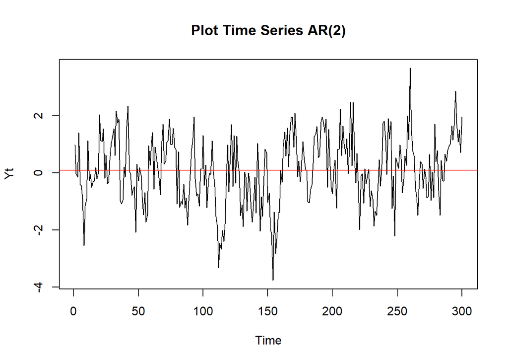

```r
# 1. Plot Time Series
plot(Yt, main = "Plot Time Series AR(2)", ylab = "Yt", type = "l")
abline(h = mean(Yt), col = "red")
```

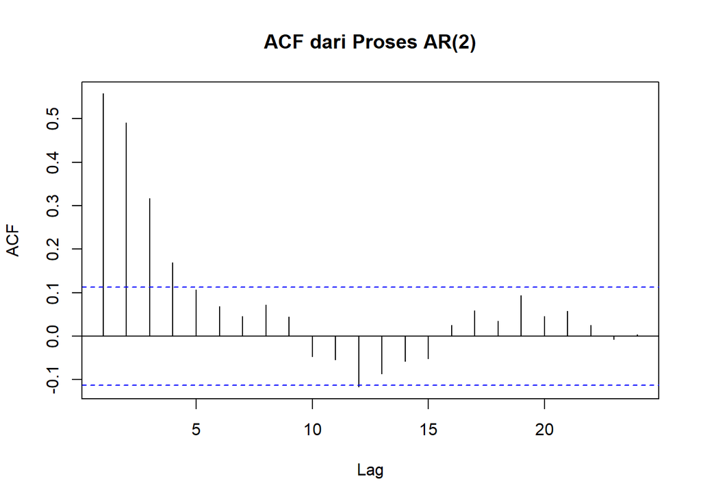

```r
# 2. Plot ACF
acf(Yt, main = "ACF dari Proses AR(2)")
```

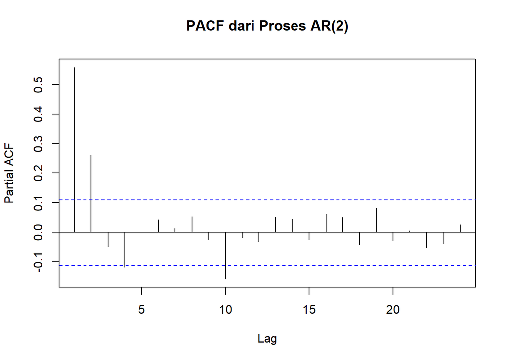

```r
# 3. Plot PACF
pacf(Yt, main = "PACF dari Proses AR(2)")
```

```r
# 4. Plot EACF
eacf(Yt)
```

```
## AR/MA
##   0 1 2 3 4 5 6 7 8 9 10 11 12 13
## 0 x x x x o o o o o o o  o  o  o
## 1 x x o o o o o o o o o  o  o  o
## 2 x x x o o o o o o o o  o  o  o
## 3 x x o o o o o o o o o  x  o  o
## 4 o x o o o o o o o o o  o  o  o
## 5 x x o o o o o o o o o  o  o  o
## 6 x x o x o o o o o o o  o  o  o
## 7 x x x x o o o o x o o  o  o  o
```

## Scatterplot

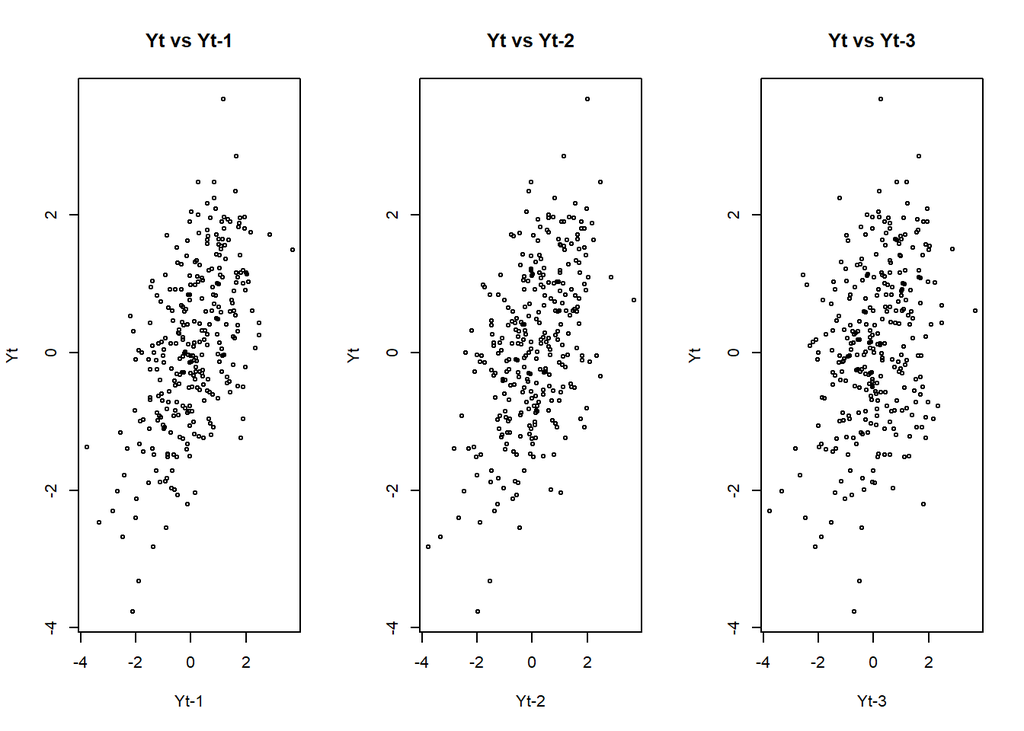

```r
# Reset layout plot
par(mfrow = c(1, 3))

# Yt vs Yt-1
plot(lag(Yt, -1), Yt, main = "Yt vs Yt-1", xlab = "Yt-1")

# Yt vs Yt-2
plot(lag(Yt, -2), Yt, main = "Yt vs Yt-2", xlab = "Yt-2")

# Yt vs Yt-3
plot(lag(Yt, -3), Yt, main = "Yt vs Yt-3", xlab = "Yt-3")
```

## Autokorelasi

### Autokorelasi Empiris (dari Data)

```r
acf_values <- acf(Yt, plot = FALSE)
print(paste("Autokorelasi Empiris Lag 1 (ρ1):", round(acf_values$acf[1], 4)))
```

```
## [1] "Autokorelasi Empiris Lag 1 (ρ1): 0.5577"
```

```r
print(paste("Autokorelasi Empiris Lag 2 (ρ2):", round(acf_values$acf[2], 4)))
```

```
## [1] "Autokorelasi Empiris Lag 2 (ρ2): 0.4913"
```

```r
print(paste("Autokorelasi Empiris Lag 3 (ρ3):", round(acf_values$acf[3], 4)))
```

```
## [1] "Autokorelasi Empiris Lag 3 (ρ3): 0.3166"
```

### Autokorelasi Teoretis

```r
# Hitung nilai teoretis
rho1_teori <- phi1 / (1 - phi2)
rho2_teori <- phi1 * rho1_teori + phi2
rho3_teori <- phi1 * rho2_teori + phi2 * rho1_teori

print(paste("Autokorelasi Teoretis Lag 1 (ρ1):", round(rho1_teori, 4)))
```

```
## [1] "Autokorelasi Teoretis Lag 1 (ρ1): 0.625"
```

```r
print(paste("Autokorelasi Teoretis Lag 2 (ρ2):", round(rho2_teori, 4)))
```

```
## [1] "Autokorelasi Teoretis Lag 2 (ρ2): 0.5125"
```

```r
print(paste("Autokorelasi Teoretis Lag 3 (ρ3):", round(rho3_teori, 4)))
```

```
## [1] "Autokorelasi Teoretis Lag 3 (ρ3): 0.3812"
```

Stasioneritas: Plot deret waktu (Time Series) menunjukkan data berfluktuasi secara stabil di sekitar rata-rata konstannya (garis merah), tanpa menunjukkan adanya tren naik atau turun. Ini adalah ciri visual dari data yang stasioner.

Identifikasi AR(2):

Plot ACF terlihat meluruh menuju nol (tails off) secara bertahap. Pola ini merupakan karakteristik dari model Autoregressive (AR).

Plot PACF secara jelas terpotong (cuts off) setelah lag ke-2. Terdapat dua spike yang signifikan secara statistik pada lag 1 dan 2, yang merupakan penanda utama untuk model AR(2).

Perbandingan Autokorelasi (Empiris vs. Teoretis) Perhitungan autokorelasi menunjukkan kecocokan yang baik antara nilai teoretis (dihitung dari persamaan Yule-Walker) dan nilai empiris (dihitung dari data).

Lag 1: Empiris (0.5577) vs Teoretis (0.625)

Lag 2: Empiris (0.4913) vs Teoretis (0.5125)

Lag 3: Empiris (0.3166) vs Teoretis (0.3812)

Meskipun ada sedikit perbedaan, nilai-nilai empiris cukup mendekati nilai teoretisnya. Perbedaan ini wajar terjadi karena adanya variasi acak (sampling variation) dalam data yang dibangkitkan.

# Nomor 3

## Bangkitkan Model ARMA(2,2)

```r
# Atur parameter
set.seed(789)
n <- 300
phi1 <- 0.5
phi2 <- 0.2
theta1 <- 0.4
theta2 <- 0.6

# Bangkitkan data menggunakan arima.sim
Yt <- arima.sim(model = list(ar = c(phi1, phi2), ma = c(-theta1, -theta2)), n = n)
```

## Plot Identifikasi dan Analisis Stasioneritas

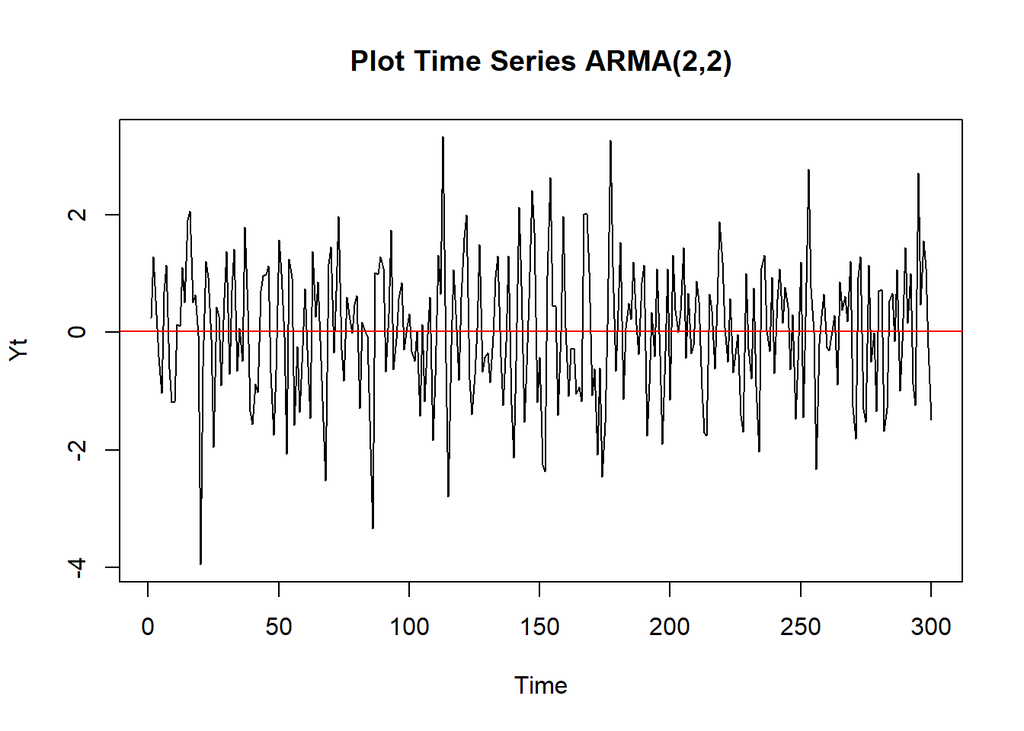

```r
# 1. Plot Time Series
plot(Yt, main = "Plot Time Series ARMA(2,2)", ylab = "Yt", type = "l")
abline(h = mean(Yt), col = "red")
```

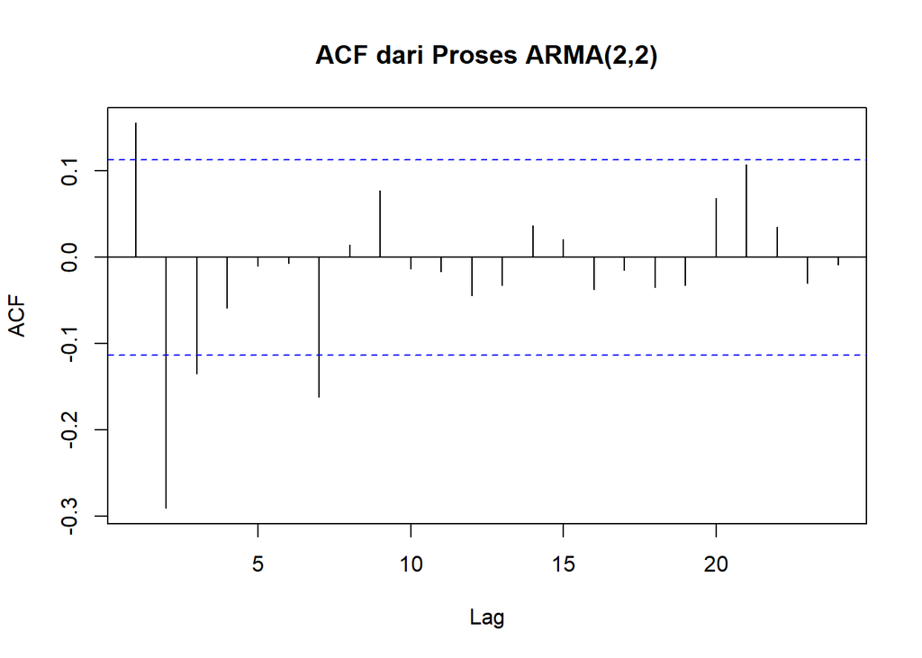

```r
# 2. Plot ACF
acf(Yt, main = "ACF dari Proses ARMA(2,2)")
```

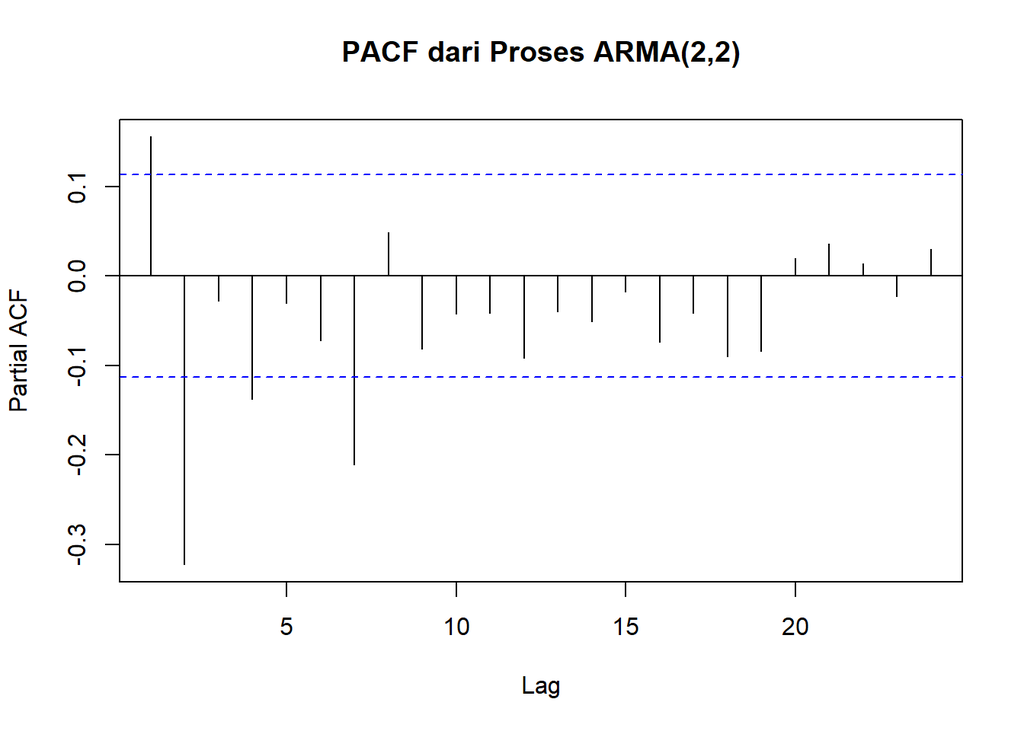

```r
# 3. Plot PACF
pacf(Yt, main = "PACF dari Proses ARMA(2,2)")
```

```r
# 4. Plot EACF
eacf(Yt)
```

```
## AR/MA
##   0 1 2 3 4 5 6 7 8 9 10 11 12 13
## 0 x x x o o o x o o o o  o  o  o
## 1 x x o o o o x o o o o  o  o  o
## 2 o x o o o o x o o o o  o  o  o
## 3 x x x o o o x o o o o  o  o  o
## 4 x x o o o o x o o o o  o  o  o
## 5 x o x o x o o x o o o  o  o  o
## 6 x o x x x x o x o o o  o  o  o
## 7 x x x x x x x x o o o  o  o  o
```

## Scatterplot

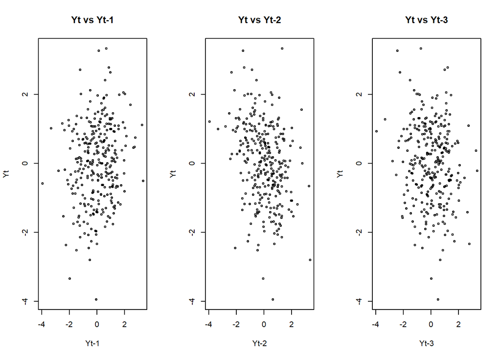

```r
# Reset layout plot
par(mfrow = c(1, 3))

# Yt vs Yt-1
plot(lag(Yt, -1), Yt, main = "Yt vs Yt-1", xlab = "Yt-1")

# Yt vs Yt-2
plot(lag(Yt, -2), Yt, main = "Yt vs Yt-2", xlab = "Yt-2")

# Yt vs Yt-3
plot(lag(Yt, -3), Yt, main = "Yt vs Yt-3", xlab = "Yt-3")
```

## Autokorelasi

### Autokorelasi Empiris (dari Data)

```r
# Hitung ACF tanpa membuat plot
acf_values <- acf(Yt, plot = FALSE)
print(paste("Autokorelasi Empiris Lag 1 (ρ1):", round(acf_values$acf[1], 4)))
```

```
## [1] "Autokorelasi Empiris Lag 1 (ρ1): 0.1555"
```

```r
print(paste("Autokorelasi Empiris Lag 2 (ρ2):", round(acf_values$acf[2], 4)))
```

```
## [1] "Autokorelasi Empiris Lag 2 (ρ2): -0.2905"
```

```r
print(paste("Autokorelasi Empiris Lag 3 (ρ3):", round(acf_values$acf[3], 4)))
```

```
## [1] "Autokorelasi Empiris Lag 3 (ρ3): -0.1343"
```

### Autokorelasi Teoretis

```r
# Hitung nilai teoretis menggunakan ARMAacf
acf_teori <- ARMAacf(ar = c(phi1, phi2), ma = c(-theta1, -theta2), lag.max = 3)

print(paste("Autokorelasi Teoretis Lag 1 (ρ1):", round(acf_teori[2], 4))) # Indeks 2 untuk lag 1
```

```
## [1] "Autokorelasi Teoretis Lag 1 (ρ1): 0.1479"
```

```r
print(paste("Autokorelasi Teoretis Lag 2 (ρ2):", round(acf_teori[3], 4))) # Indeks 3 untuk lag 2
```

```
## [1] "Autokorelasi Teoretis Lag 2 (ρ2): -0.2239"
```

```r
print(paste("Autokorelasi Teoretis Lag 3 (ρ3):", round(acf_teori[4], 4))) # Indeks 4 untuk lag 3
```

```
## [1] "Autokorelasi Teoretis Lag 3 (ρ3): -0.0824"
```

Stasioneritas: Plot deret waktu (Time Series) menunjukkan data berfluktuasi secara stabil di sekitar rata-ratanya (garis merah), tanpa adanya tren. Ini adalah ciri visual dari data yang stasioner.

Identifikasi ARMA(2,2):

Plot ACF dan PACF: Berbeda dengan model AR atau MA murni, untuk model campuran ARMA, kedua plot (ACF dan PACF) sama-sama meluruh menuju nol (tails off). Mereka tidak memiliki pola terpotong (cut off) yang jelas, yang merupakan indikasi kuat dari model campuran.

Matriks EACF: Meskipun tidak sejelas pada contoh sebelumnya, matriks EACF menunjukkan pola segitiga berisi nol (‘o’) yang ujungnya dapat diinterpretasikan berada pada baris AR=2 dan kolom MA=2. Ini adalah alat identifikasi yang paling membantu untuk model campuran dan menunjuk ke ARMA(2,2).

Perbandingan Autokorelasi (Empiris vs. Teoretis)

Perhitungan autokorelasi menunjukkan kecocokan yang baik antara nilai teoretis dan nilai empiris yang dihitung dari data bangkitan:

Lag 1: Empiris (0.1555) vs Teoretis (0.1479)

Lag 2: Empiris (-0.2905) vs Teoretis (-0.2239)

Lag 3: Empiris (-0.1343) vs Teoretis (-0.0824)

Meskipun ada sedikit perbedaan (yang wajar terjadi karena variasi acak), nilai-nilai empiris secara umum mengikuti pola dan besaran nilai teoretisnya. Ini mengonfirmasi bahwa simulasi data ARMA(2,2) telah berhasil.